# UFO Geostatistics

Michael Ramsey

February 21, 2019

# Spatial Statistics of UFO Data

The National UFO Reporting Center (NUFORC) is an organization in the United States that investigates UFO sightings and/or alien contacts. NUFORC has been in continuous operation since 1974 when it was founded by Robert J. Gribble. It has catalogued almost 90,000 reported UFO sightings over its history, most of which were in the United States. The data analyzed here contains information on 64,506 UFO sightings over the last century. The data contain lon/lat coordinates, state, shape of the UFO, the date and time as well as the duration (in seconds) of the sighting. We will investigate the spatial structure of the dataset. Here is a snapshot of the data.

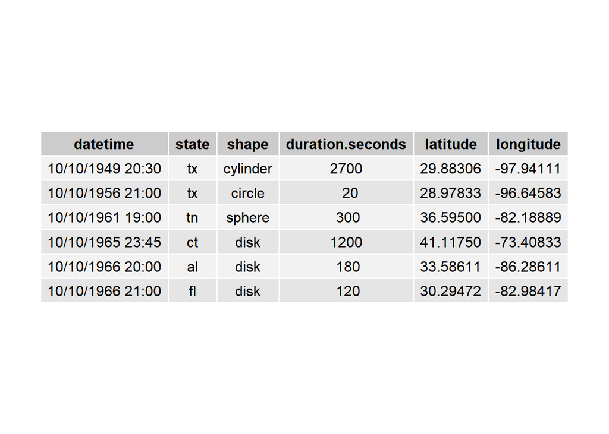

# Data Visualization

### Sightings by state

We start by displaying a map of the United States where each point represents the geographic location of a ufo sighting. The second U.S. map displays a heat-map by state, where the color of the state represents the number of sightings in that state. Note that this map is slightly misleading, since will large states will naturally have more sightings than smaller ones. I should normalize by state population, however I did not attempt to find population data. It seems that the sightings are concentrated around areas of large population. I add points for all cities with population over 40,000 in red.

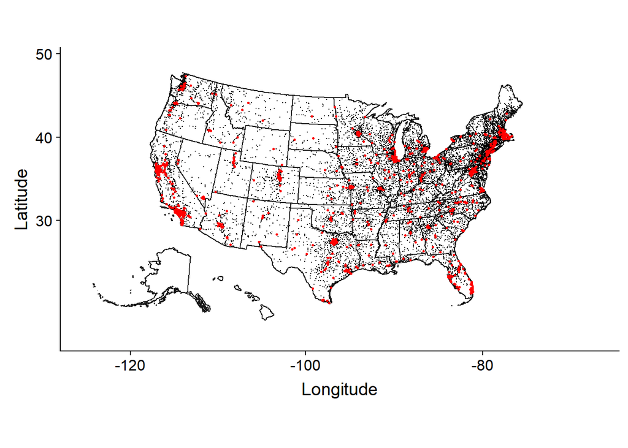

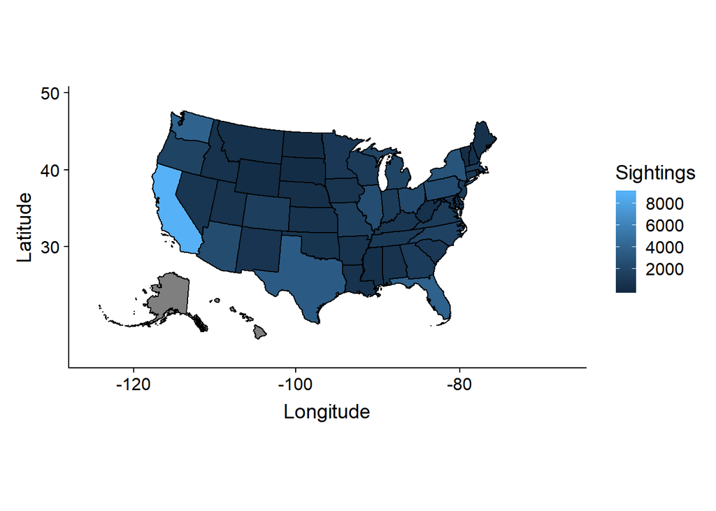

### Counts of sightings by shape

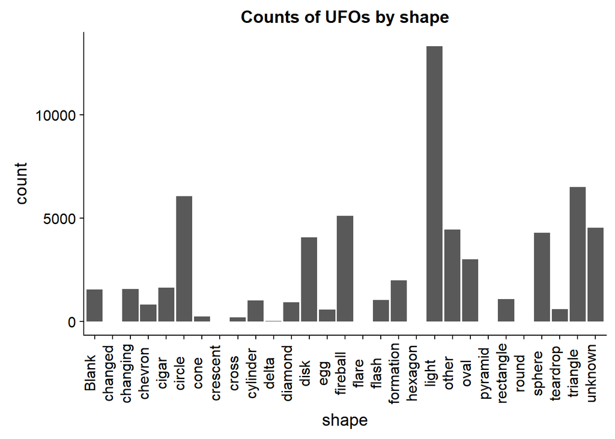

We see that, by far, the most common shape is “light”, followed by “triangle”, then “circle”. There are 29 different shapes recorded.

### Distriubtion of sighting lengths

Sighting length was converted to log scale due to the large skewness in the data.

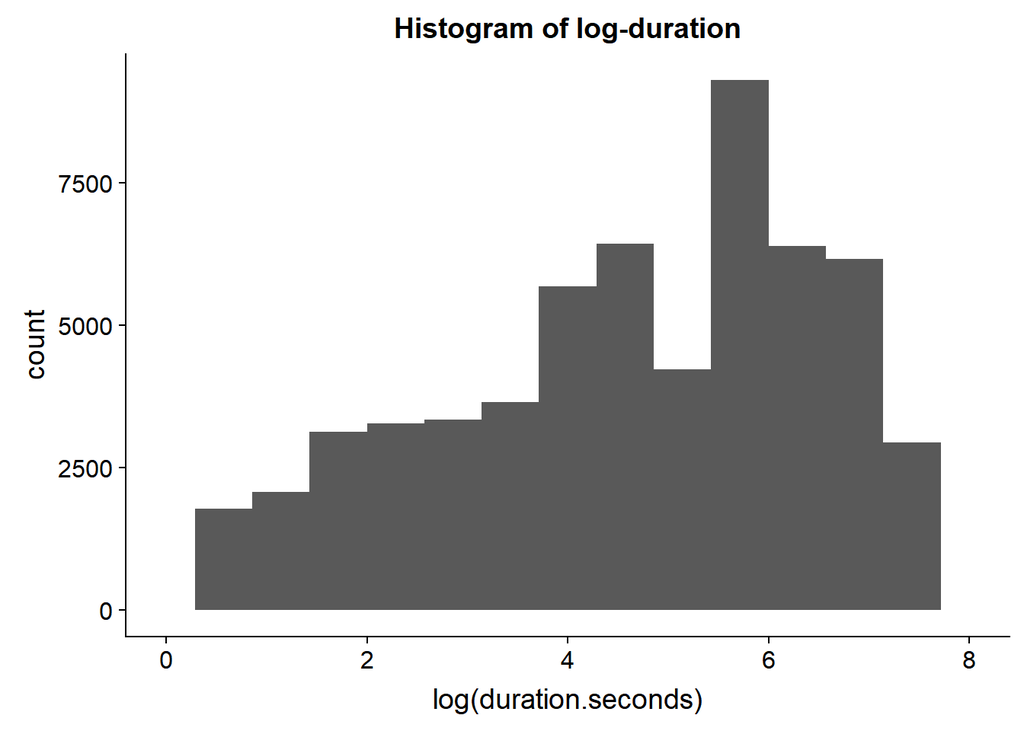

I also provide a summary of the duration and log-duration for reference on these values.

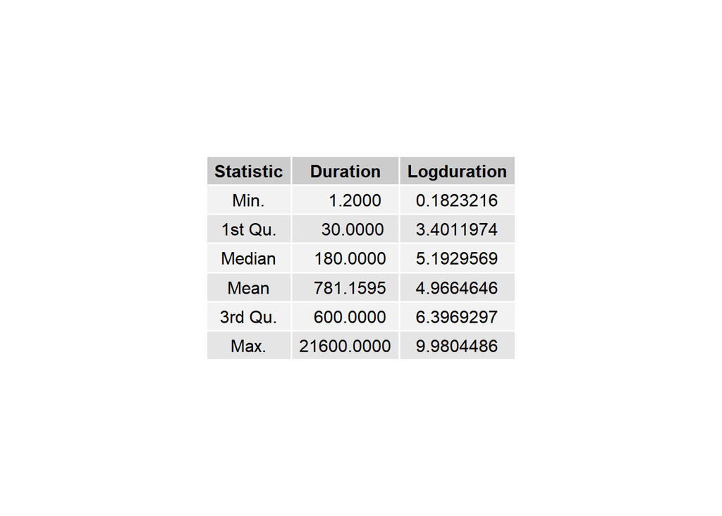

# Spatial Modeling

### Spatial dependence of duration

For several states, I construct a heat map for the log-duration of the sighting at each sighting location. In other words, points on the following plot represent sighting geographic location, and color represent the duration of the sighting in log scale.

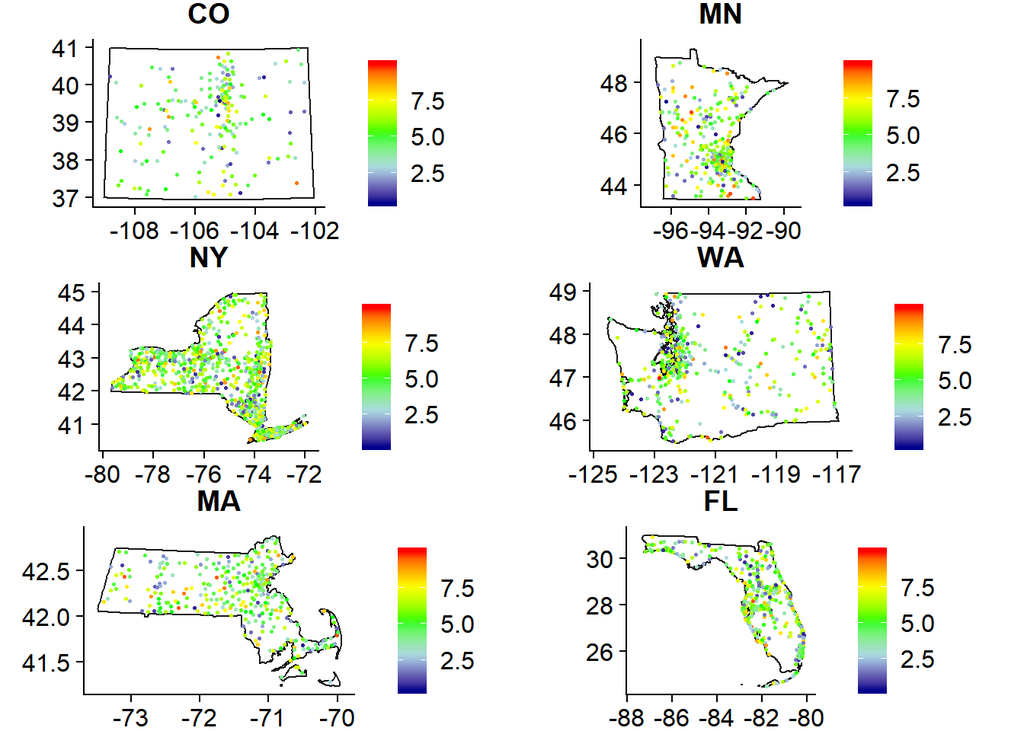

It appears there may be spatial correlation in the data. There appears to be clumps of green in several states, however we know color can be misleading. I will also produce a heat map using the fields package to add another visual reference.

### Fields package

Using the fields package, we get the following plots.

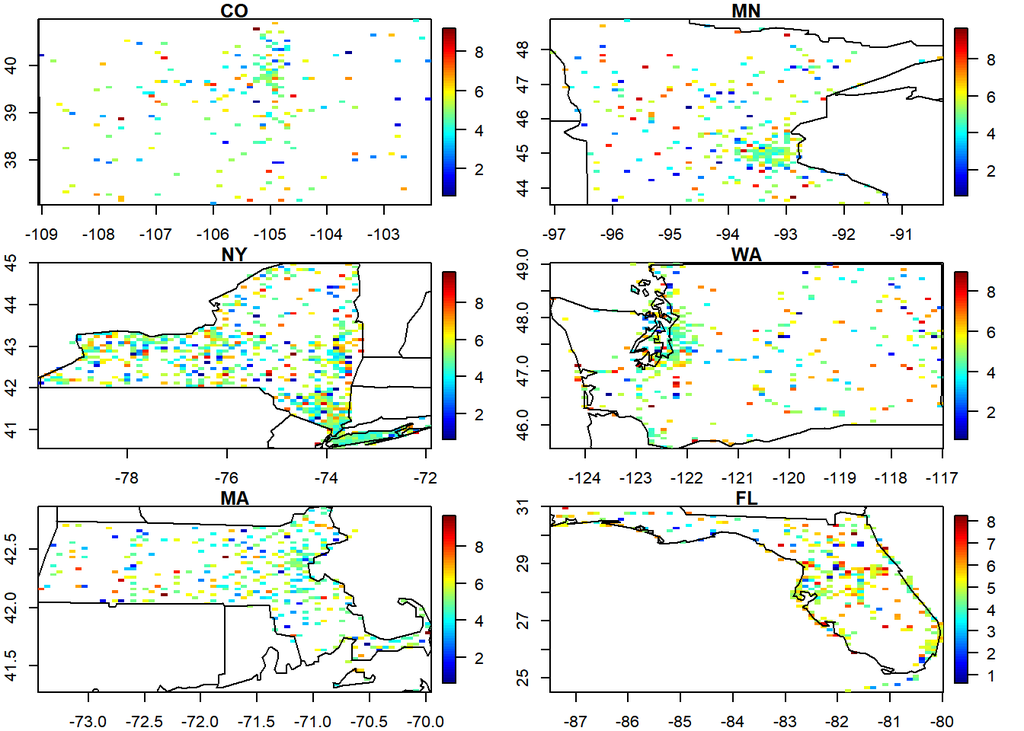

We can still see some clumps of colors. This tells us that spatial correlation may be present in the data. Now let’s attempt to further visualize and model the covariance structrues in a subset of states. I choose New York (NY), Massachusettes (MA), and Arizona (AZ).

# Binned semicovariogram of log-duration for NY

I will model correlations using two packages: fields and geor.

### Fields package

I construct a binned semicoariogram for log-duration using the vgram function in the fields package. In the following plot, I display a scatter plot for the number of data points per bin.

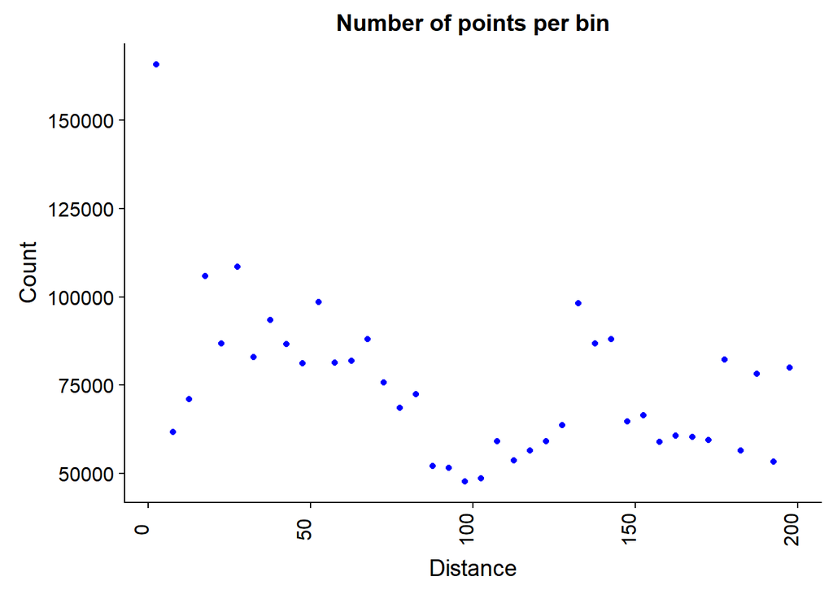

We see that there are a ton of distances within the first bin of the semi-covariogram. We may be averaging over too many points, and thus unable to see if there is spatial dependence at small distances. We try this again, but increasing the number of bins to 300.

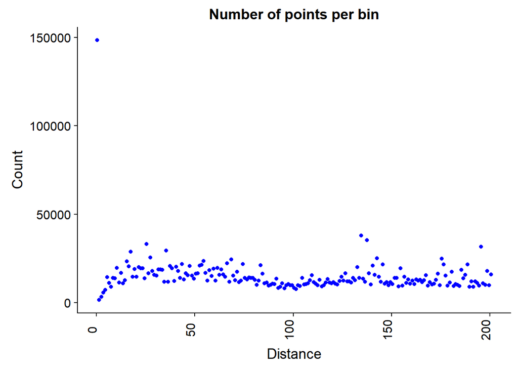

Now we finally plot the binned semi-covariogram.

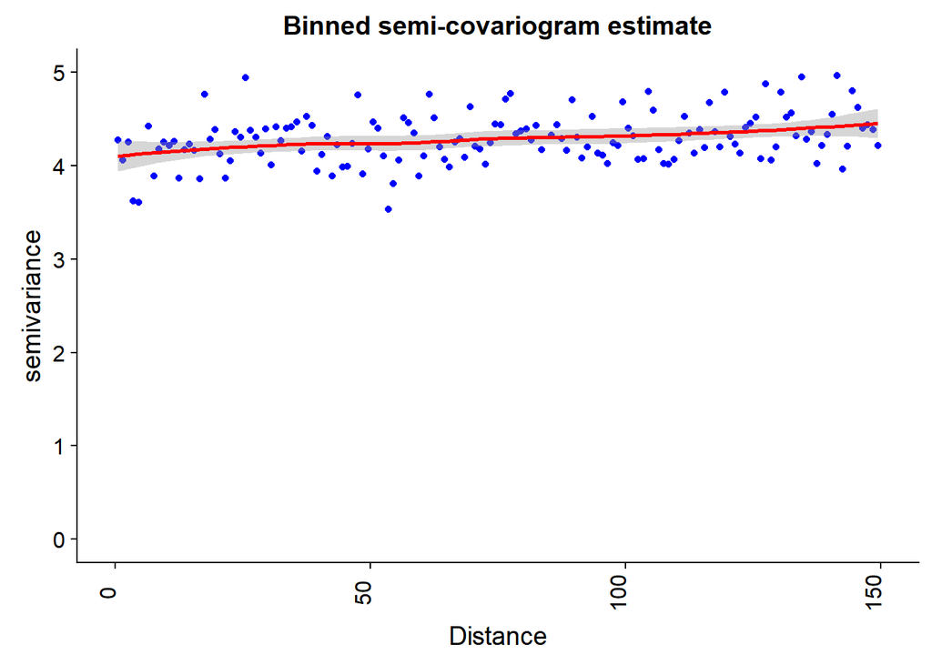

There does not appear to be any spatial correlation in the data.

### geoR package

We now do the same thing using the geor package. We note a technical difficulty here: geoR only accepts projected coordinates, so we lose some interpretability here. I display a plot of the original vs. projected coordinates for your reference. I also estimate variograms using two methods, classical binning and robust binning. I display both results, but I ultimately used the robust binning when I move on to parameter estimation of covariance functions.

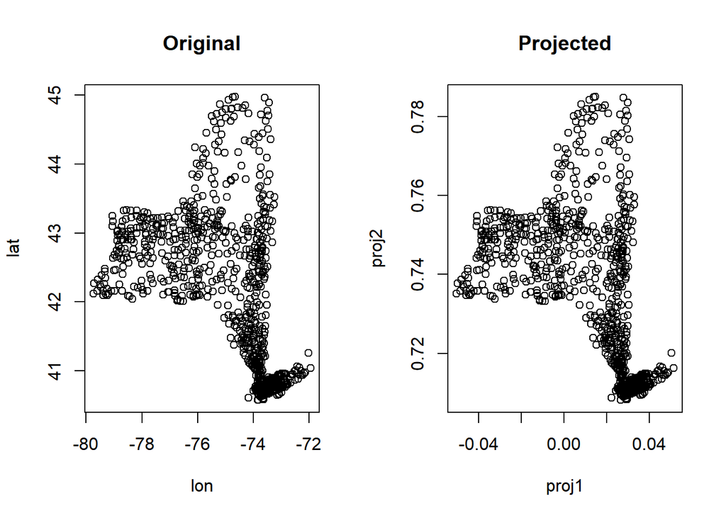

```
## variog: computing omnidirectional variogram
## variog: co-locatted data found, adding one bin at the origin
```

```
## variog: computing omnidirectional variogram
## variog: co-locatted data found, adding one bin at the origin
```

```
## variog: computing omnidirectional variogram
## variog: co-locatted data found, adding one bin at the origin
```

```
## variog: computing omnidirectional variogram
## variog: co-locatted data found, adding one bin at the origin
```

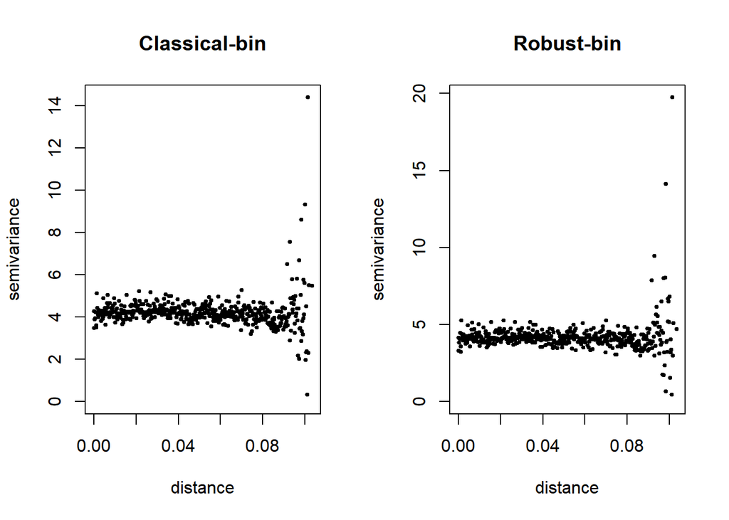

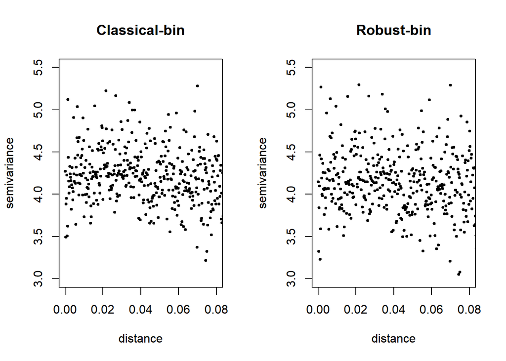

Again, we do not see any spatial correlation in the data.

### Fitting Covariance Functions

I fit several different covariance functions to the data. It’s difficult to determine an optimal function in terms of best fit. This is due to the noisyness of the data.

```
## variofit: covariance model used is exponential
## variofit: weights used: cressie
## variofit: minimisation function used: optim
## variofit: searching for best initial value ... selected values:
##               sigmasq phi    tausq  kappa
## initial.value "9.88"  "0.08" "1.98" "0.5"
## status        "est"   "est"  "est"  "fix"
## loss value: 856528.403131728
```

```
## variofit: covariance model used is powered.exponential
## variofit: weights used: cressie
## variofit: minimisation function used: optim
## variofit: searching for best initial value ... selected values:
##               sigmasq phi    tausq  kappa
## initial.value "9.88"  "0.08" "1.98" "0.5"
## status        "est"   "est"  "est"  "fix"
## loss value: 760802.303967983
```

```
## variofit: covariance model used is matern
## variofit: weights used: cressie
## variofit: minimisation function used: optim
## variofit: searching for best initial value ... selected values:
##               sigmasq phi    tausq  kappa
## initial.value "9.88"  "0.08" "4.94" "1"
## status        "est"   "est"  "est"  "fix"
## loss value: 562141.211378616
```

```
## variofit: covariance model used is spherical
## variofit: weights used: cressie
## variofit: minimisation function used: optim
## variofit: searching for best initial value ... selected values:
##               sigmasq phi    tausq  kappa
## initial.value "9.88"  "0.08" "1.98" "0.5"
## status        "est"   "est"  "est"  "fix"
## loss value: 1240070.66456273
```

```
## variofit: covariance model used is pure.nugget
## variofit: weights used: cressie
```

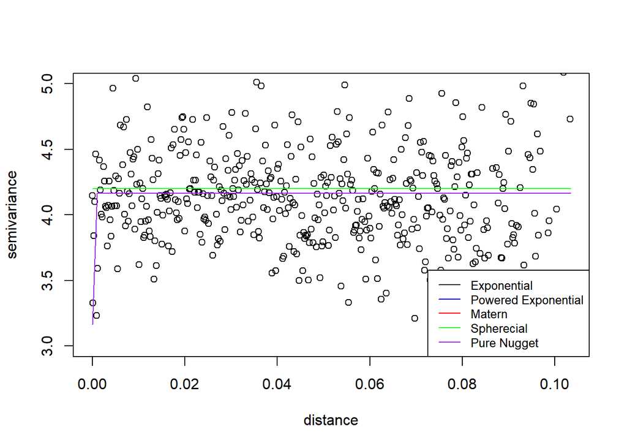

### WLS Prediciton

I arbitrarily choose the exponential covariance model to estimate model parameters via weighted least squares. Our predictors are longitude and latitude. I display a table of the parameter estimates and the standard errors.

```r
# We use the exponential covariance model
vfit <- variofit(v.bc.r,cov.model="exponential",weights="cressie")
```

```
## variofit: covariance model used is exponential
## variofit: weights used: cressie
## variofit: minimisation function used: optim
## variofit: searching for best initial value ... selected values:
##               sigmasq phi    tausq  kappa
## initial.value "9.88"  "0.08" "1.98" "0.5"
## status        "est"   "est"  "est"  "fix"
## loss value: 856528.403131728
```

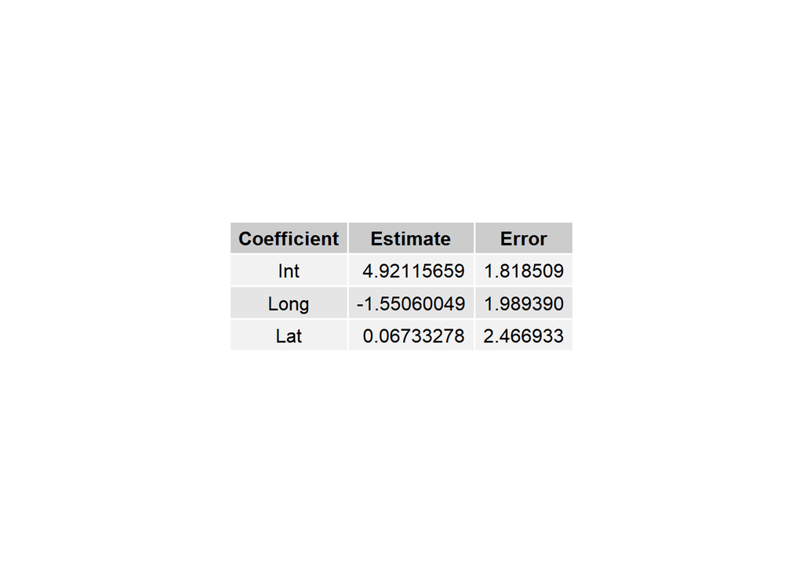

```r
# Extract nugget effect
tau2 <- vfit$nugget # tau^2

# Extract covariance function parameters
sigma2 <- vfit$cov.pars[1] # sigma^2
a <- vfit$cov.pars[2] # a = range as exp(-r/a)

# Set up covariance matrix Sigma - for exponential model
Sigma <- sigma2 * exp(-rdist(grd.p)/a)
diag(Sigma) <- diag(Sigma) + tau2 # Add nugget

# Construct regression matrix
X <- cbind(1,grd.p)

# Solve WLS
beta.gls <- solve(t(X) %*% solve(Sigma) %*% X) %*% t(X) %*% solve(Sigma) %*% ny$logdur

# Compute standard errors
beta.gls.se <- sqrt(diag(solve(t(X) %*% solve(Sigma) %*% X)))

# Put coefficients and intercept in a table
wmod <- data.frame(Coefficient = c('Int','Long','Lat'),
                   Estimate = beta.gls,
                   Error = beta.gls.se)

# Display the results
grid.table(wmod,rows = NULL)
```

### OLS Prediction

I also compute model parameters using ordinary least squares for comparison. With this model, we assume that there is no spatial correlation in the data. This corresponds to the “pure nugget” covariance model.

[figure not shown]

```r
# Create linear model
mylm <- lm(ny$logdur~grd.p)

# Put coefficients and intercept in a table
lmod <- data.frame(Coefficient = c('Int','Long','Lat'),
                   Estimate = unname(summary(mylm)$coef[,2]),
                   Error = unname(summary(mylm)$coef[,3]))

# Display the results
grid.table(lmod,rows = NULL)
```

# Binned semicovariogram of log-duration for Massachusettes

I will model correlations using two packages: fields and geor.

### Fields package

I construct a binned semicoariogram for log-duration using the vgram function in the fields package. In the following plot, I display a scatter plot for the number of data points per bin.

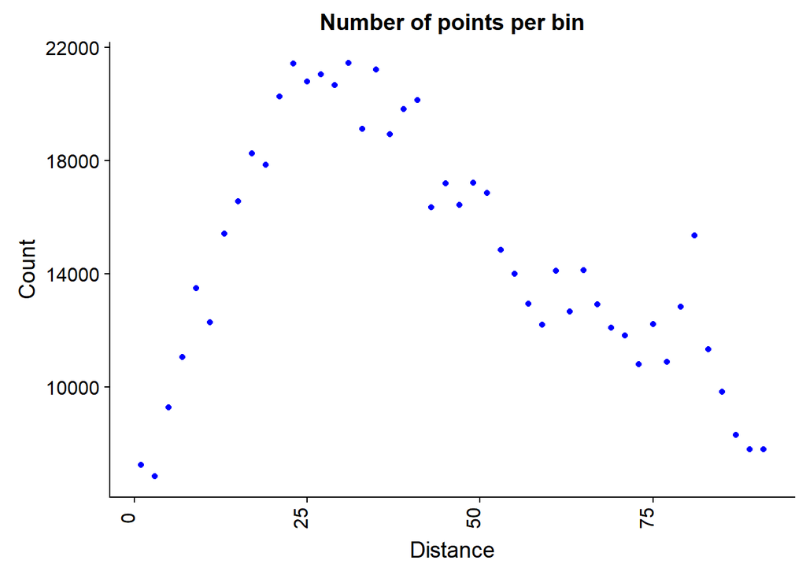

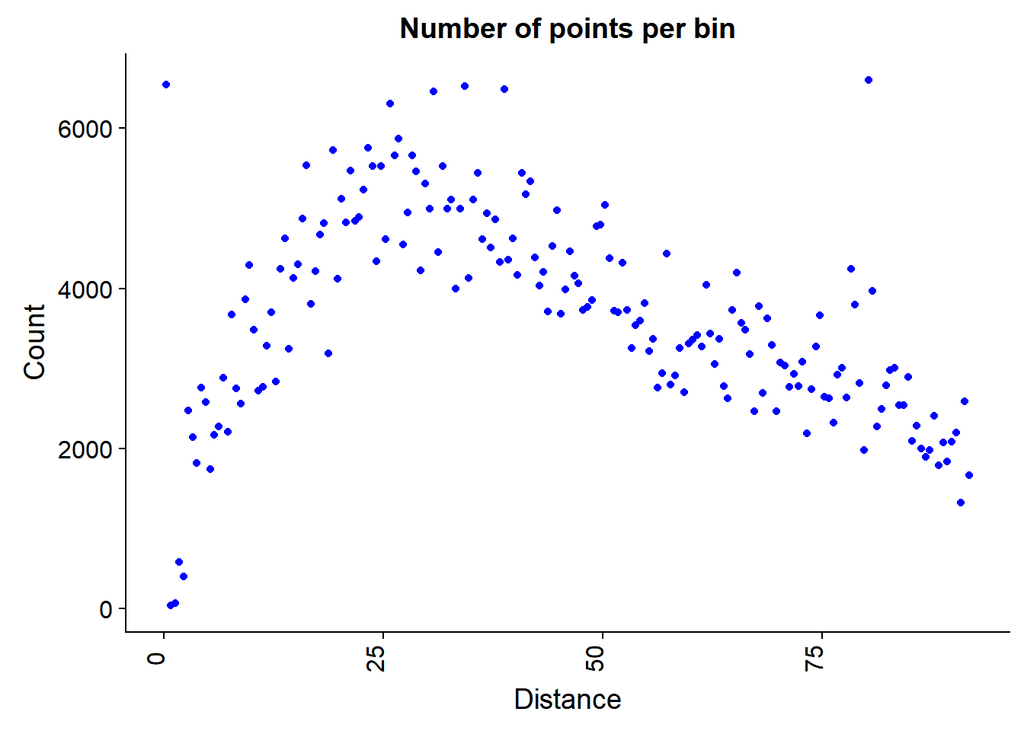

Now we finally plot the binned semi-covariogram.

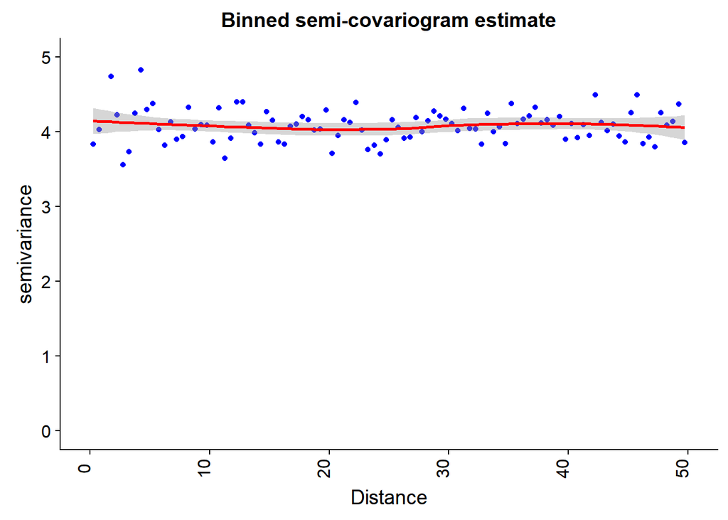

There does not appear to be any spatial correlation in the data.

### geoR package

We now do the same thing using the geor package. We note a technical difficulty here: geoR only accepts projected coordinates, so we lose some interpretability here. I display a plot of the original vs. projected coordinates for your reference. I also estimate variograms using two methods, classical binning and robust binning. I display both results, but I ultimately used the robust binning when I move on to parameter estimation of covariance functions.

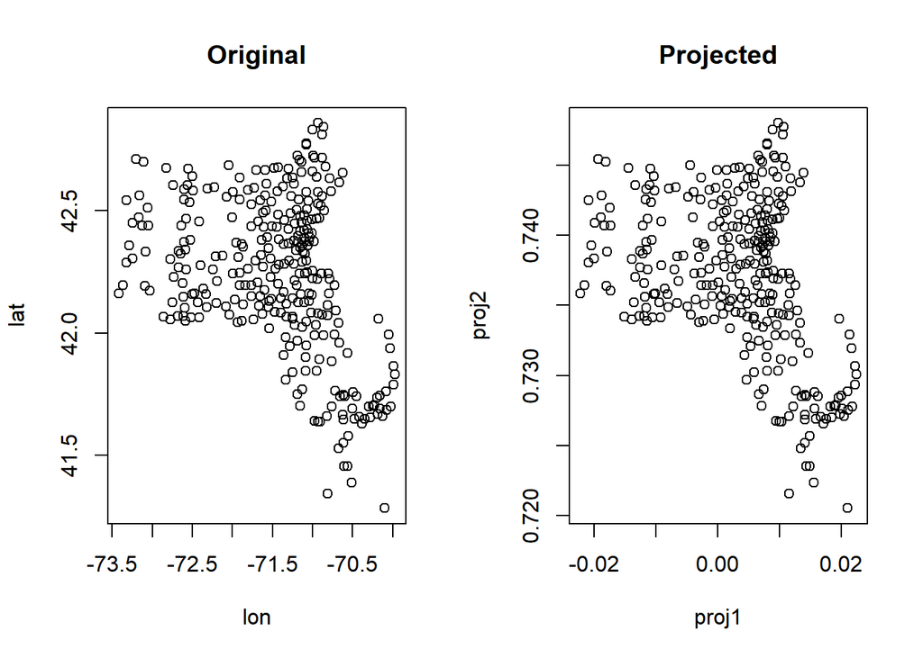

```
## variog: computing omnidirectional variogram
## variog: co-locatted data found, adding one bin at the origin
```

```
## variog: computing omnidirectional variogram
## variog: co-locatted data found, adding one bin at the origin
```

```
## variog: computing omnidirectional variogram
## variog: co-locatted data found, adding one bin at the origin
```

```
## variog: computing omnidirectional variogram
## variog: co-locatted data found, adding one bin at the origin
```

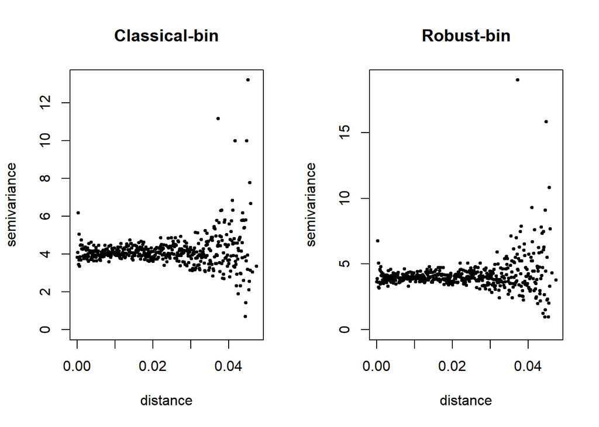

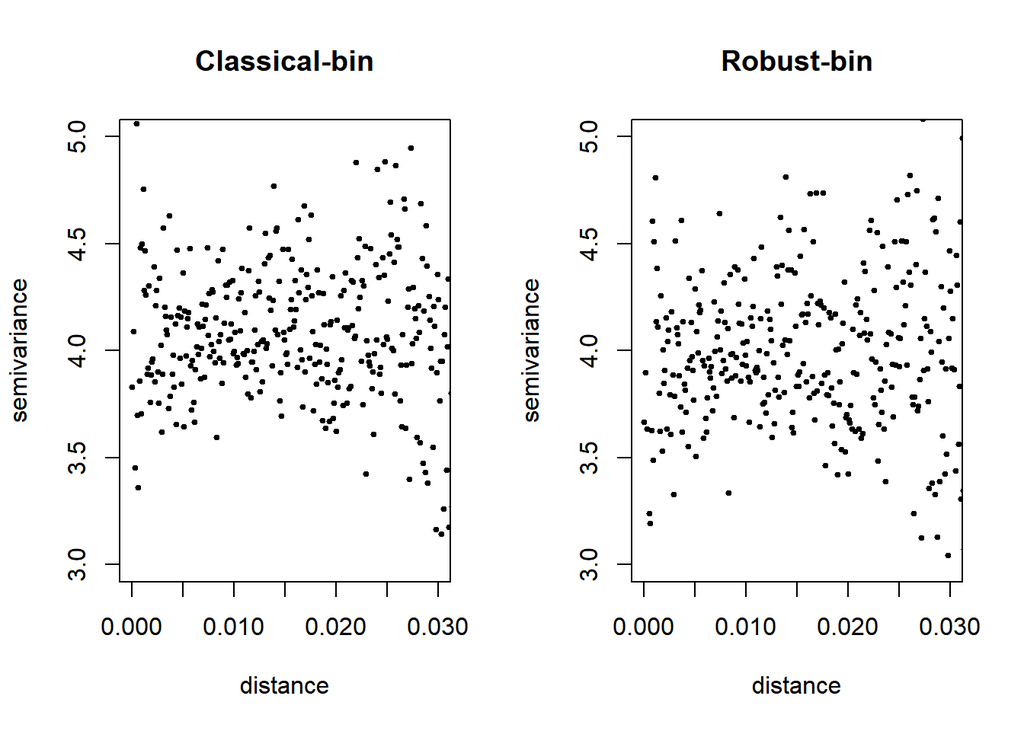

### Fitting Covariance Functions

I fit several different covariance functions to the data. It’s difficult to determine an optimal function in terms of best fit. This is due to the noisyness of the data.

```
## variofit: covariance model used is exponential
## variofit: weights used: cressie
## variofit: minimisation function used: optim
## variofit: searching for best initial value ... selected values:
##               sigmasq phi    tausq kappa
## initial.value "9.51"  "0.04" "1.9" "0.5"
## status        "est"   "est"  "est" "fix"
## loss value: 83752.0425708344
```

```
## variofit: covariance model used is powered.exponential
## variofit: weights used: cressie
## variofit: minimisation function used: optim
## variofit: searching for best initial value ... selected values:
##               sigmasq phi    tausq kappa
## initial.value "9.51"  "0.04" "1.9" "0.5"
## status        "est"   "est"  "est" "fix"
## loss value: 88515.0944936507
```

```
## variofit: covariance model used is matern
## variofit: weights used: cressie
## variofit: minimisation function used: optim
## variofit: searching for best initial value ... selected values:
##               sigmasq phi    tausq  kappa
## initial.value "9.51"  "0.04" "4.75" "1"
## status        "est"   "est"  "est"  "fix"
## loss value: 74866.5031034221
```

```
## variofit: covariance model used is spherical
## variofit: weights used: cressie
## variofit: minimisation function used: optim
## variofit: searching for best initial value ... selected values:
##               sigmasq phi    tausq kappa
## initial.value "9.51"  "0.04" "1.9" "0.5"
## status        "est"   "est"  "est" "fix"
## loss value: 137685.393315694
```

```
## variofit: covariance model used is pure.nugget
## variofit: weights used: cressie
```

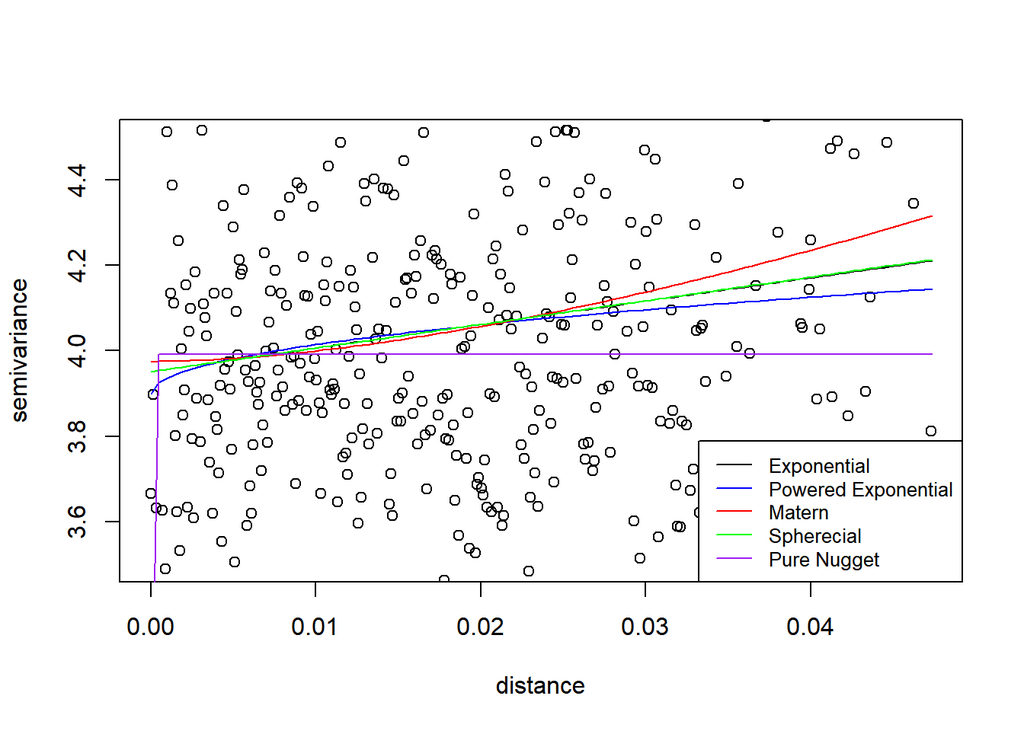

### WLS Prediciton

I arbitrarily choose the powered exponential covariance model to estimate model parameters via weighted least squares. Our predictors are longitude and latitude. I display a table of the parameter estimates and the standard errors.

```
## variofit: covariance model used is powered.exponential
## variofit: weights used: cressie
## variofit: minimisation function used: optim
## variofit: searching for best initial value ... selected values:
##               sigmasq phi    tausq kappa
## initial.value "9.51"  "0.04" "1.9" "0.5"
## status        "est"   "est"  "est" "fix"
## loss value: 88515.0944936507
```

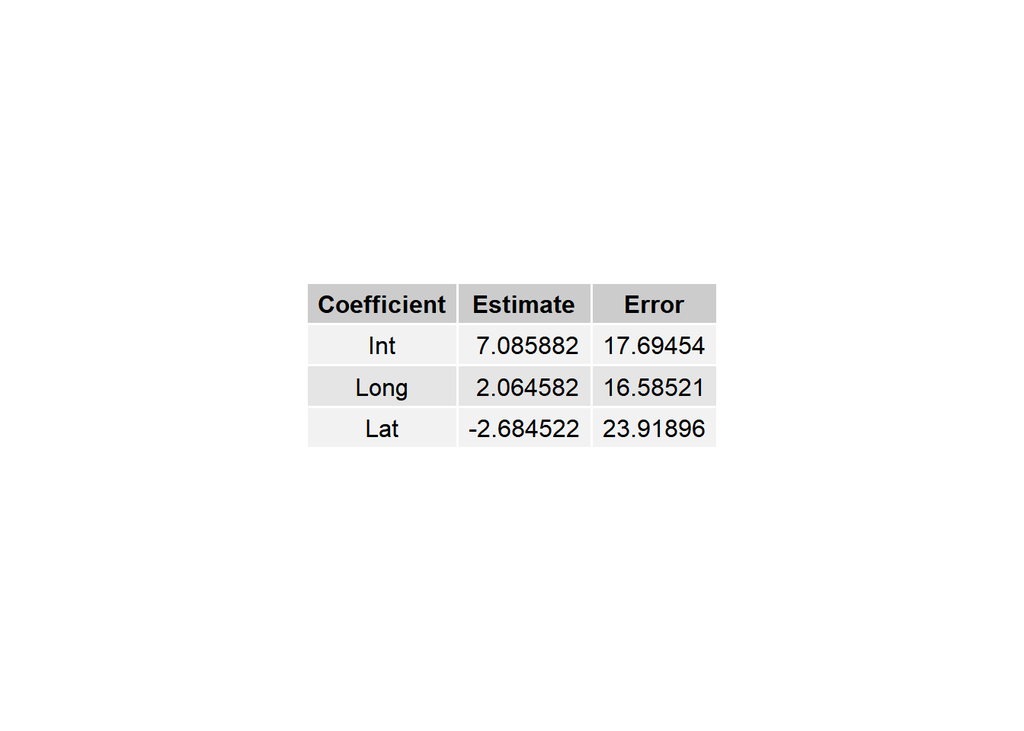

### OLS Prediction

I also compute model parameters using ordinary least squares for comparison. With this model, we assume that there is no spatial correlation in the data. This corresponds to the “pure nugget” covariance model.

[figure not shown]

# Binned semicovariogram of log-duration for Arizona

I will model correlations using two packages: fields and geor.

### Fields package

I construct a binned semicoariogram for log-duration using the vgram function in the fields package. In the following plot, I display a scatter plot for the number of data points per bin.

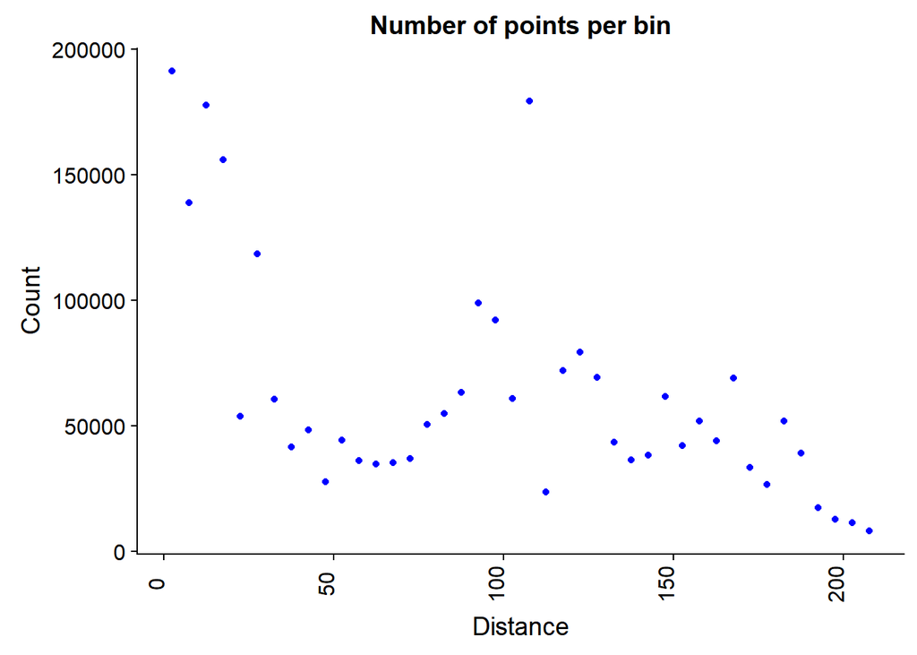

Now we finally plot the binned semi-covariogram.

[figure not shown]

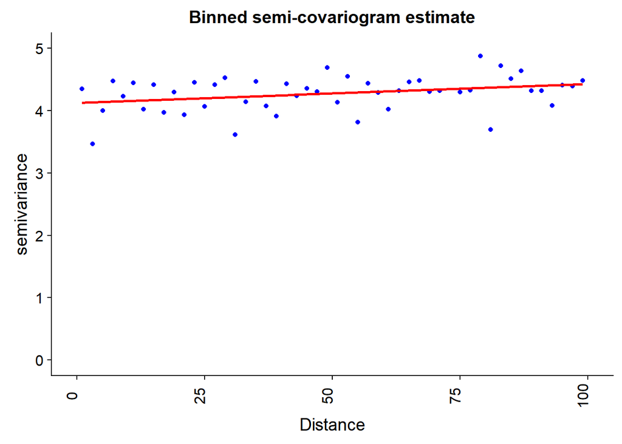

There does not appear to be much spatial correlation in the data.

### geoR package

We now do the same thing using the geor package. We note a technical difficulty here: geoR only accepts projected coordinates, so we lose some interpretability here. I display a plot of the original vs. projected coordinates for your reference. I also estimate variograms using two methods, classical binning and robust binning. I display both results, but I ultimately used the robust binning when I move on to parameter estimation of covariance functions.

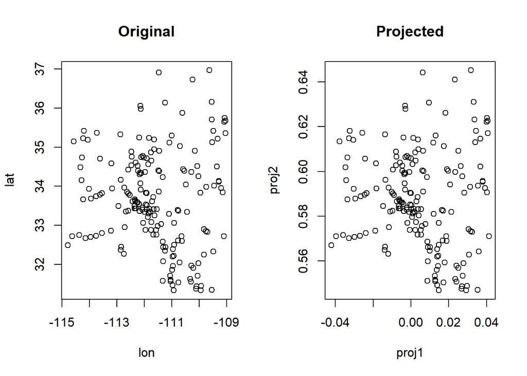

```
## variog: computing omnidirectional variogram
## variog: co-locatted data found, adding one bin at the origin
```

```
## variog: computing omnidirectional variogram
## variog: co-locatted data found, adding one bin at the origin
```

```
## variog: computing omnidirectional variogram
## variog: co-locatted data found, adding one bin at the origin
```

```
## variog: computing omnidirectional variogram
## variog: co-locatted data found, adding one bin at the origin
```

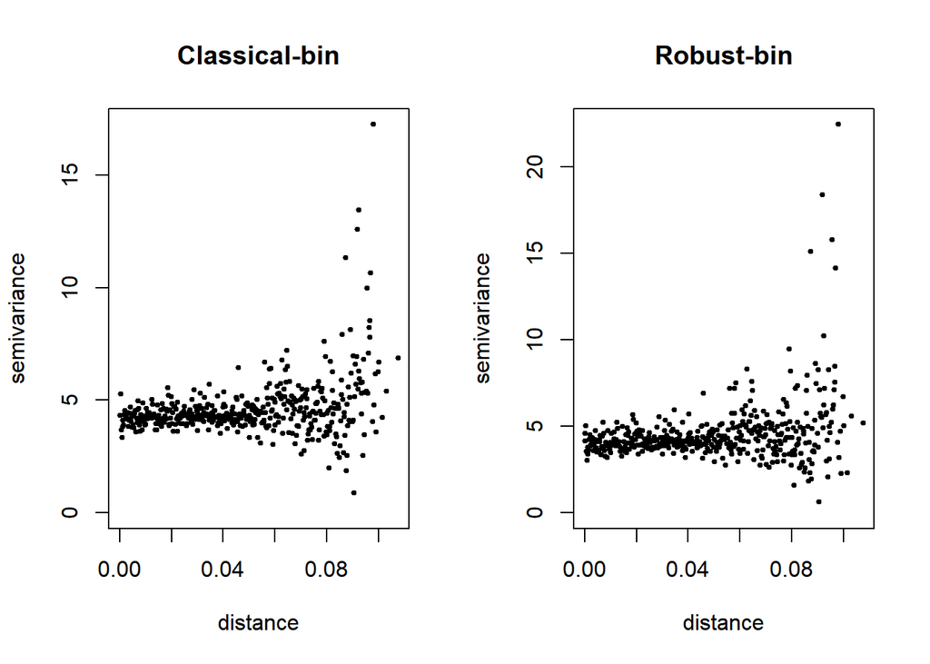

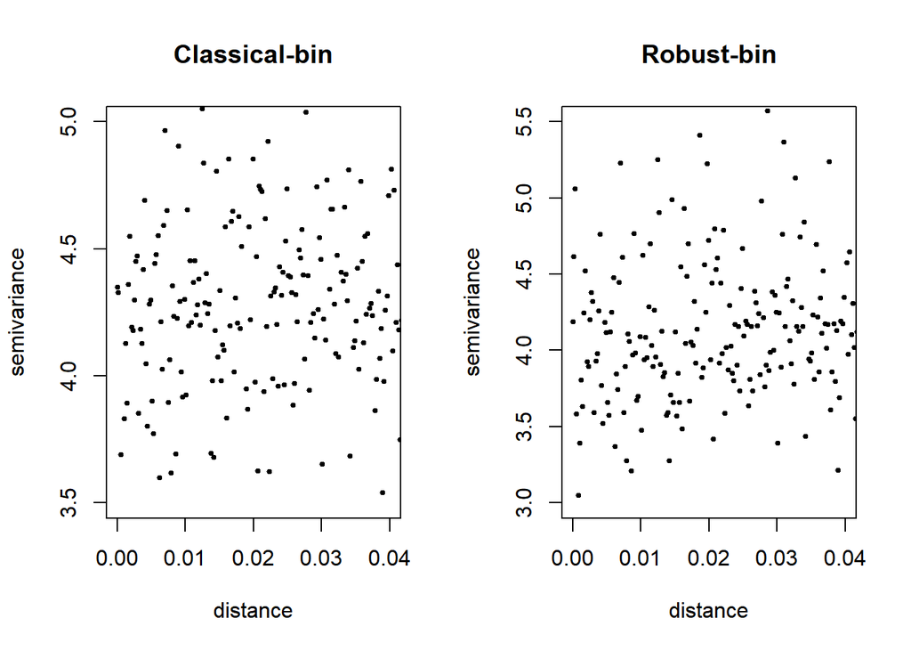